# **QM 640, Capstone Project**

# **Learner's name: Rajan Nadpurohit**

## **Learner's program: Walsh MS in AIML**

### **Learner's batch: Batch 'A', Sept 2025**

[figure not shown]

# **Title of the Project: Investigating Revenue Growth Influence on Liquidity Leverage System Behaviour: A ROCE Based Analysis of Indian Auto Component Manufacturers (Annual Revenue INR 70 to 410 Cr, Year ending March 2025).**

## **Objectives of the Project**

## **i) To quantify the Liquidity Leverage System by developing a composite Liquidity Index (LI) and structural Debt to Equity (D/E) measures.**

## **ii) To analyse the direct impact of individual forces (Liquidity, Leverage, and Revenue Growth) on the efficiency metric, ROCE (Modigliani & Miller, 1958).**

## **iii) To identify "Friction Zones" by modelling the two way interactions between liquidity, leverage, and growth.**

## **iv) To evaluate System Stability through a three way interaction model (β7) to see how firms perform when all three forces collide under stress (Dawson, 2014).**

### **Loading the Dataset and confirming it is properly loaded**

```python
import pandas as pd

# I've added the quotes around your GitHub link below
url = 'https://github.com/NadRaj17/Rajan-Data-analytic-Project-Repository/raw/refs/heads/main/QM%20640,%20Consolidated%20Data,%20Rajan%20Nadpurohit.csv'

df = pd.read_csv(url)
```

```python
import pandas as pd

# Set the maximum number of rows to show to 10 or more
pd.set_option('display.max_rows', 10)

# Now, when you call df, it will show the first 5 and last 5
df
```

|  | Company | Year_End | ROCE% | LI | D/E | Revenue Growth % | LI*D/E | LI*Revenue Growth % | D/E*Revenue Growth % | LI*D/E*Revenue Growth % |
| --- | --- | --- | --- | --- | --- | --- | --- | --- | --- | --- |
| 0 | 1 | M25 | 12.92 | 0.88 | 0.90 | -13.34 | 0.79 | -11.72 | -12.01 | -10.55 |
| 1 | 1 | M24 | 19.41 | 0.87 | 1.04 | -8.83 | 0.90 | -7.66 | -9.18 | -7.97 |
| 2 | 1 | M23 | 22.49 | 0.48 | 1.33 | -0.40 | 0.64 | -0.19 | -0.54 | -0.26 |
| 3 | 1 | M22 | 27.04 | 0.40 | 1.11 | 69.91 | 0.44 | 27.93 | 77.60 | 31.01 |
| 4 | 1 | M21 | 12.82 | 0.74 | 1.16 | 13.59 | 0.86 | 10.07 | 15.76 | 11.68 |
| ... | ... | ... | ... | ... | ... | ... | ... | ... | ... | ... |
| 100 | 21 | M25 | 17.17 | 0.98 | 0.56 | 0.00 | 0.55 | 0.00 | 0.00 | 0.00 |
| 101 | 21 | M24 | 22.33 | 0.99 | 0.47 | -0.85 | 0.46 | -0.83 | -0.39 | -0.39 |
| 102 | 21 | M23 | 6.39 | 0.90 | 0.59 | 20.34 | 0.53 | 18.28 | 11.96 | 10.75 |
| 103 | 21 | M22 | 6.84 | 0.91 | 0.46 | 24.47 | 0.41 | 22.18 | 11.20 | 10.15 |
| 104 | 21 | M21 | 10.15 | 0.98 | 0.33 | -8.14 | 0.33 | -8.00 | -2.69 | -2.65 |

105 rows × 10 columns

### **Checking for Missing values in the dataset df**

```python
# Check for missing values in each column
print("Missing values per column:")
print(df.isnull().sum())
```

```
Missing values per column:
Company                    0
Year_End                   0
ROCE%                      0
LI                         0
D/E                        0
Revenue Growth %           0
LI*D/E                     0
LI*Revenue Growth %        0
D/E*Revenue Growth %       0
LI*D/E*Revenue Growth %    0
dtype: int64
```

### **Checking for duplicate records**

```python
# Count total number of duplicate rows
duplicate_count = df.duplicated().sum()

print(f"Total duplicate rows: {duplicate_count}")

# If you want to see the actual duplicate rows (if any exist):
if duplicate_count > 0:
    print("\nDuplicate Rows:")
    display(df[df.duplicated()])
```

```
Total duplicate rows: 0
```

```python
df.info()
```

```
<class 'pandas.core.frame.DataFrame'>
RangeIndex: 105 entries, 0 to 104
Data columns (total 10 columns):
 #   Column                   Non-Null Count  Dtype
---  ------                   --------------  -----
 0   Company                  105 non-null    int64
 1   Year_End                 105 non-null    object
 2   ROCE%                    105 non-null    float64
 3   LI                       105 non-null    float64
 4   D/E                      105 non-null    float64
 5   Revenue Growth %         105 non-null    float64
 6   LI*D/E                   105 non-null    float64
 7   LI*Revenue Growth %      105 non-null    float64
 8   D/E*Revenue Growth %     105 non-null    float64
 9   LI*D/E*Revenue Growth %  105 non-null    float64
dtypes: float64(8), int64(1), object(1)
memory usage: 8.3+ KB
```

**Converting Company variable to a Category datatype:**

Since the numbers in the Company column are IDs (labels) and not values I do not want to do math on them (like adding Company 1 to Company 2). Hence, it is best to convert them to a string or category.

```python
# Convert Company variable to string/object
df['Company'] = df['Company'].astype(str)
```

**Handling Year_End (M21 to M25)**

To plot them chronologically, I will want to treat them as a Categorical variable with a specific order.

```python
# Define the correct chronological order
year_order = ['M21', 'M22', 'M23', 'M24', 'M25']

# Convert Year_End to a categorical type with that order
df['Year_End'] = pd.Categorical(df['Year_End'], categories=year_order, ordered=True)
```

## **EDA**

### **Understanding the behaviour of all the 8 variables**

ROCE% is our Dependant Variable, while the remaining are our Predictors (Independant variables)

```
--- Statistical Summary of Financial Variables (Consolidated) ---
```

|  | count | mean | std | min | Q1 | Median | Q3 | max | skewness | kurtosis |
| --- | --- | --- | --- | --- | --- | --- | --- | --- | --- | --- |
| ROCE% | 105.0 | 18.664476 | 9.677391 | -5.82 | 11.25 | 17.17 | 27.04 | 40.84 | 0.251543 | -0.523071 |
| LI | 105.0 | 1.292857 | 0.956602 | 0.40 | 0.81 | 0.98 | 1.32 | 5.68 | 2.752394 | 8.268681 |
| D/E | 105.0 | 0.697905 | 0.624758 | 0.00 | 0.20 | 0.55 | 1.04 | 3.16 | 1.016157 | 1.140269 |
| Revenue Growth % | 105.0 | 14.602000 | 24.673725 | -65.52 | -1.76 | 11.71 | 29.33 | 101.32 | 0.389305 | 1.460755 |
| LI*D/E | 105.0 | 0.606476 | 0.492392 | 0.00 | 0.25 | 0.55 | 0.82 | 2.59 | 1.165040 | 2.016734 |
| LI*Revenue Growth % | 105.0 | 15.209048 | 30.415326 | -76.34 | -1.36 | 11.61 | 30.46 | 115.11 | 0.206741 | 1.731198 |
| D/E*Revenue Growth % | 105.0 | 13.806000 | 29.383102 | -62.28 | -0.02 | 1.38 | 15.76 | 112.76 | 1.435834 | 2.673456 |
| LI*D/E*Revenue Growth % | 105.0 | 11.330476 | 25.816410 | -68.00 | -0.04 | 2.23 | 14.03 | 121.23 | 1.429874 | 5.245421 |

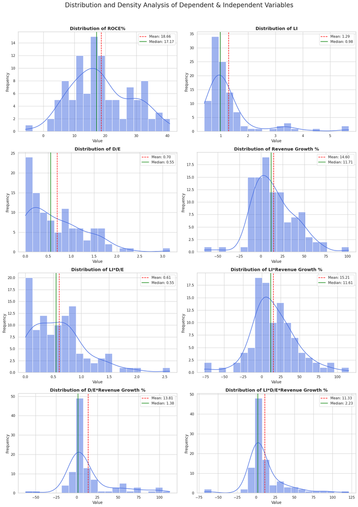

```python
import pandas as pd
import seaborn as sns
import matplotlib.pyplot as plt

# 1. Define the 8 variables
variables = ['ROCE%', 'LI', 'D/E', 'Revenue Growth %', 'LI*D/E',
             'LI*Revenue Growth %', 'D/E*Revenue Growth %', 'LI*D/E*Revenue Growth %']

# 2. Generate Statistical Summary with the 5-number summary + Skew/Kurtosis
# .describe() automatically includes Min, 25%(Q1), 50%(Median), 75%(Q3), and Max
summary = df[variables].describe().T

# Adding Skewness and Kurtosis
summary['skewness'] = df[variables].skew()
summary['kurtosis'] = df[variables].kurtosis()

# Renaming columns for clarity in your report
summary = summary.rename(columns={'25%': 'Q1', '50%': 'Median', '75%': 'Q3'})

print("--- Statistical Summary of Financial Variables (Consolidated) ---")
display(summary[['count', 'mean', 'std', 'min', 'Q1', 'Median', 'Q3', 'max', 'skewness', 'kurtosis']])

# 3. Distribution Curve with KDE in a 4x2 Grid
sns.set_theme(style="whitegrid")
fig, axes = plt.subplots(nrows=4, ncols=2, figsize=(16, 22))
fig.suptitle('Distribution and Density Analysis of Dependent & Independent Variables', fontsize=20, y=1.02)

axes = axes.flatten()

for i, var in enumerate(variables):
    sns.histplot(df[var], kde=True, ax=axes[i], color='royalblue', bins=20)

    # Adding vertical lines for Mean and Median to help your interpretation
    axes[i].axvline(df[var].mean(), color='red', linestyle='--', label=f'Mean: {df[var].mean():.2f}')
    axes[i].axvline(df[var].median(), color='green', linestyle='-', label=f'Median: {df[var].median():.2f}')

    axes[i].set_title(f'Distribution of {var}', fontsize=14, fontweight='bold')
    axes[i].set_xlabel('Value')
    axes[i].set_ylabel('Frequency')
    axes[i].legend()

plt.tight_layout()
plt.show()
```

### **Interpreting the Statistical Summary**

**1. ROCE% (The Dependent Variable)**

Performance: The Mean (18.66%) and Median (17.17%) are very close, suggesting a relatively balanced distribution. This is a healthy return for mid-cap manufacturing.

Normality: The low Skewness (0.25) and negative Kurtosis (-0.52) indicate that ROCE% follows a nearly normal, slightly "flat" distribution. This is excellent for our regression analysis as it minimizes the need for complex data transformations.

Risk: However, the Min (-5.82) shows at least one company faced a loss or capital erosion during this period.

**2. LI (Liquidity Index) - The Most Skewed Variable**

The "Outlier" Alert: This variable has the highest Skewness (2.75) and a very high Kurtosis (8.26).

Interpretation: While the Median is 0.98, the Max is 5.68. This tells us that most companies maintain a tight liquidity position (around 1.0), but a few specific manufacturers are sitting on massive cash reserves or liquid assets. This "fat tail" could disproportionately influence our regression results.

**3. D/E (Debt-to-Equity)**

Leverage Profile: The Median (0.55) suggests that the typical mid-cap auto component firm is moderately leveraged.

**4. Revenue Growth % (The High Volatility Metric)**

Extreme Variance: Looking at the Std Dev (24.67) compared to the Mean (14.60). It indicates massive inconsistency in growth across the sector.

The Sector "Pain": The Min (-65.52) is startling. It shows that during this M21-M25 window, some companies saw their revenues more than halve in a single year, likely due to supply chain disruptions or the transition to EVs.

Recovery: Conversely, the Max (101.32) shows others doubled their revenue. This wide gap makes Revenue Growth % a very powerful predictor in our model.

**5. Interaction Terms (The Multipliers)**

Interpretation: This is expected mathematically, but it confirms that the combined effect of high liquidity, high debt, and high growth creates "extreme" financial profiles.

It suggests that the interaction of these factors creates a "compounding effect" on a company's ROCE.

### **Interpreting the Distribution curves**

**1. The "Well-Behaved" Variable:**

ROCE%: The ROCE% plot is the closest to a Normal Distribution (Bell Curve).

Interpretation: While there is a slight right skew (as the mean is higher than the median), the data is spread relatively evenly around the 15-20% mark. This suggests that the "Capital Efficiency" of mid-cap auto firms in India is stable and predictable across your sample.

**2. The "Highly Skewed" Ratios:**

LI and D/EBoth Liquidity (LI) and Debt-to-Equity (D/E) show a strong Positive (Right) Skew.

LI Interpretation: Most companies are clustered around a liquidity of 1.0 (the green median line), but we can see "long-tail" outliers stretching out toward 5.0. This shows a few companies are hoarding cash, while the majority operate lean.

D/E Interpretation: The tall bar at the far left shows many companies have very low debt ($0.0$ to $0.5$). The curve "thins out" as it moves right, indicating that high leverage is the exception, not the rule, in this sector.

**3. The "Bimodal & Volatile" Metric: Revenue Growth %**

This is perhaps your most interesting graph.

**4. The "Compressed" Interaction Terms**

The four interaction terms (bottom four plots) show a very high concentration of data points near zero, with very long, thin tails.

Interpretation: This "Leptokurtic" shape (very peaked) happens because when one multiply ratios like D/E and LI, the result for most companies stays small.

Critical Insight: The extreme outliers on the right of these interaction plots represent "High-Risk/High-Reward" companies, those that have high debt, high liquidity, and high growth simultaneously. These few observations will likely have a disproportionate impact on our regression results.

**Strategic Insight:**

Because of the "Long Tails" seen in LI, D/E, and the Interaction terms, "The data exhibits non-normality in independent variables, which justifies the use of a Robust Regression or Fixed Effects model to handle potential outlier influence."

**Generating the Correlation Heatmap**

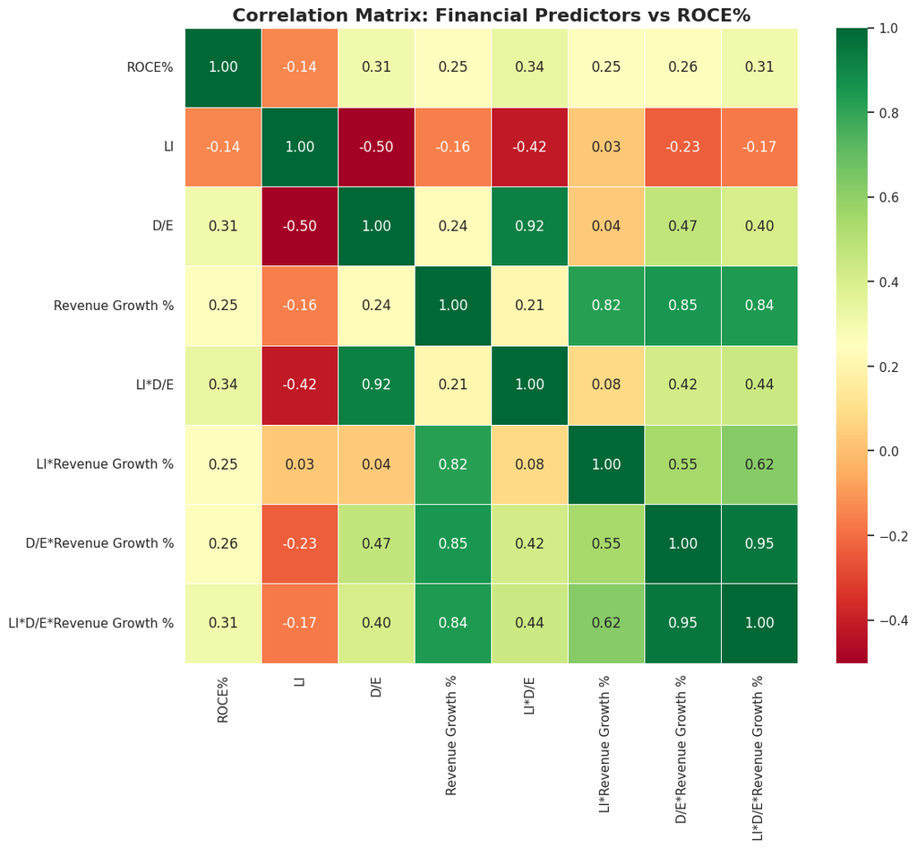

```python
# Calculate the correlation matrix
corr_matrix = df[variables].corr()

# Plotting the heatmap
plt.figure(figsize=(12, 10))
sns.heatmap(corr_matrix, annot=True, cmap='RdYlGn', fmt=".2f", linewidths=0.5)

plt.title('Correlation Matrix: Financial Predictors vs ROCE%', fontsize=16, fontweight='bold')
plt.show()
```

### **Interpretation of the correlation matrix:**

**1. The Drivers of ROCE% (The Top Row)**

Strongest Positive Predictors: LI*D/E (0.34) and D/E (0.31) along with the full interaction term LI*D/E*Revenue Growth % (0.31).

Insight:

Interestingly, debt (D/E) has a positive correlation with ROCE in this mid-cap sample. This suggests that these companies might be successfully using "Financial Leverage" to boost their returns on capital.

The Growth Link:

Revenue Growth % (0.25) has a moderate positive correlation. This confirms that sales expansion does contribute to capital efficiency, but perhaps not as strongly as the way the company is structured financially (leverage/liquidity).

The Negative Link:

LI (-0.14) is the only variable negatively correlated with ROCE.

Insight:

This suggests that "Excess Liquidity" might be a drag on performance. If a company holds too much idle cash (high LI) instead of deploying it into production, the return on its total capital (ROCE) drops.

**2. Multicollinearity Warnings (The "Dark Green" Clusters)**

One can see the very high numbers (0.80 to 0.95) in the bottom right quadrant.

The Issue:

Variables like D/E*Revenue Growth % and LI*D/E*Revenue Growth % are correlated at 0.95.

Project Impact:

When we run our regression, including all these interaction terms at once might cause "Multicollinearity." This doesn't mean the data is wrong, but it means the model might struggle to tell which specific interaction is doing the "heavy lifting."

**3. The "Trade-off" (LI vs. D/E)**

There is a significant negative correlation (-0.50) between LI and D/E.

Insight:

This makes perfect sense in corporate finance. Companies with high debt (high D/E) generally have lower liquidity (low LI) because they are using their cash to service debt or expand. Conversely, cash-rich companies tend to avoid borrowing.

### **Summary:**

**"The preliminary correlation analysis indicates that capital structure (D/E) and the interaction of liquidity with leverage (LI*D/E) are the primary positive drivers of ROCE% in the sampled mid-cap auto component firms. However, high idle liquidity appears to have a marginal diminishing effect on returns. The strong inter-correlations between interaction terms suggest that the final regression model must be carefully structured to account for multicollinearity."**

### **Trend Analysis**

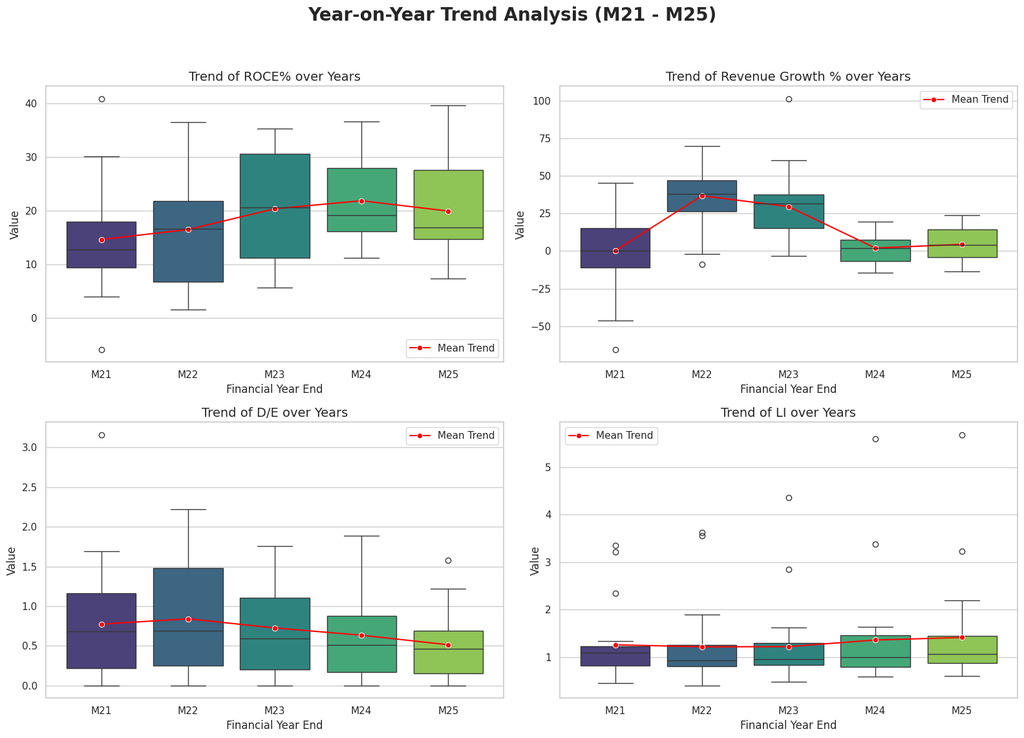

```python
import matplotlib.pyplot as plt
import seaborn as sns

# Defining the primary variables to track over time
time_vars = ['ROCE%', 'Revenue Growth %', 'D/E', 'LI']

# Setting up a 2x2 grid for time-series analysis
fig, axes = plt.subplots(nrows=2, ncols=2, figsize=(16, 12))
fig.suptitle('Year-on-Year Trend Analysis (M21 - M25)', fontsize=20, fontweight='bold')

axes = axes.flatten()

for i, var in enumerate(time_vars):
    # Using a Boxplot to see the distribution per year
    sns.boxplot(x='Year_End', y=var, data=df, ax=axes[i], palette='viridis', showfliers=True)

    # Overlaying a Lineplot of the Mean to see the clear trend
    sns.lineplot(x='Year_End', y=var, data=df, ax=axes[i], color='red', marker='o', label='Mean Trend', errorbar=None)

    axes[i].set_title(f'Trend of {var} over Years', fontsize=14)
    axes[i].set_ylabel('Value')
    axes[i].set_xlabel('Financial Year End')
    axes[i].legend()

plt.tight_layout(rect=[0, 0.03, 1, 0.95])
plt.show()
```

### **Trend analysis:**

It tells a clear story of a sector that went through a massive "cycle" between M21 and M25.

### **Interpretation of the Year-on-Year trends:**

**1. The Revenue Growth "Rollercoaster"**

The Surge (M21 to M22):

One can see a massive jump in the mean (red line). M21 was near zero (likely the pandemic-induced slowdown), followed by a sharp "reopening" surge in M22.

The Normalization (M23 to M25):

One can see that the boxes get "shorter" and the mean settles down. By M24 and M25, the industry moved from high-growth recovery to a low-growth steady state. This is a classic industry lifecycle phase.

**2. ROCE%: The Lagging Recovery**

Steady Climb:

Interestingly, while revenue growth peaked in M22, ROCE% continued to climb until M24.

Insight:

This suggests that mid-cap auto firms became more efficient after the initial sales surge. They optimized their operations and capital usage, leading to better returns even as sales growth slowed down.

M25 Dip: There is a slight dip in the mean ROCE% in M25. One might need to investigate if this was due to rising input costs or heavy R&D investments in new component technologies.

**3. Deleveraging: The D/E Trend**

Decreasing Debt: The mean D/E ratio has been on a consistent downward slope from M22 to M25.

Strategic Narrative:

As these companies grew and improved their ROCE, they used their profits to pay down debt (deleveraging) rather than borrowing more. This makes the sector financially more robust as of M25.

**4. Liquidity (LI):**

Stability with Outliers

Consistency: The "boxes" for LI are remarkably consistent year-over-year, with the median staying near 1.0.

The "Cash Rich" outliers:

The dots stretching up toward 5.0 every year. There are a few specific companies in our dataset that persistently carry high liquidity regardless of the industry cycle.

### **Summary:**

**"The longitudinal analysis reveals a sector that successfully transitioned from a high-growth recovery phase (M22) into a period of capital efficiency and debt reduction (M24-M25). While revenue growth normalized, the improvement in ROCE and the reduction in D/E suggest an overall strengthening of the financial health of Indian mid-cap auto component manufacturers."**

### **Check for Multicollinearity (VIF)**

The Variance Inflation Factor (VIF) measures how much an independent variable is "inflated" by its correlation with others. A VIF above 5 or 10 usually signals a problem.

```python
from statsmodels.stats.outliers_influence import variance_inflation_factor
import statsmodels.api as sm

# Select your 7 independent variables
X = df[['LI', 'D/E', 'Revenue Growth %', 'LI*D/E',
        'LI*Revenue Growth %', 'D/E*Revenue Growth %', 'LI*D/E*Revenue Growth %']]

# Add a constant (required for VIF calculation)
X_with_const = sm.add_constant(X)

# Calculate VIF
vif_data = pd.DataFrame()
vif_data["Variable"] = X_with_const.columns
vif_data["VIF"] = [variance_inflation_factor(X_with_const.values, i) for i in range(X_with_const.shape[1])]

print("--- Multicollinearity Check (VIF) ---")
print(vif_data)
```

```
--- Multicollinearity Check (VIF) ---
                  Variable        VIF
0                    const   8.740211
1                       LI   1.430801
2                      D/E  13.884988
3         Revenue Growth %  12.150052
4                   LI*D/E  12.632069
5      LI*Revenue Growth %   5.117473
6     D/E*Revenue Growth %  26.847614
7  LI*D/E*Revenue Growth %  21.649906
```

### **Check for Heteroscedasticity (Breusch-Pagan Test)**

In a good regression model, the "errors" (residuals) should have constant variance. If the variance changes (e.g., higher error for larger companies), your results might be unreliable.

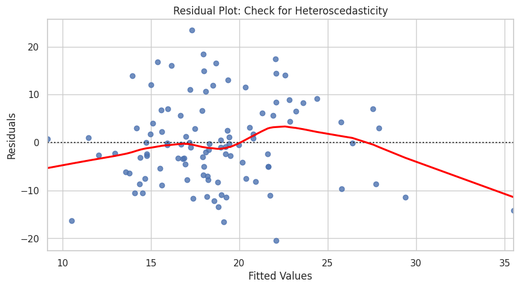

```
--- Breusch-Pagan Test Results ---
{'LM Statistic': np.float64(10.116411359865378), 'LM-Test p-value': np.float64(0.18207197178399823), 'F-Statistic': np.float64(1.4774373463777386), 'F-Test p-value': np.float64(0.18429307984962437)}
```

```python
from statsmodels.stats.diagnostic import het_breuschpagan
import matplotlib.pyplot as plt
import seaborn as sns

# Run a preliminary OLS regression to get the residuals
y = df['ROCE%']
model = sm.OLS(y, X_with_const).fit()
residuals = model.resid
fitted_values = model.fittedvalues

# 1. Visual Check: Residual Plot
plt.figure(figsize=(10, 5))
sns.residplot(x=fitted_values, y=residuals, lowess=True, line_kws={'color': 'red'})
plt.title('Residual Plot: Check for Heteroscedasticity')
plt.xlabel('Fitted Values')
plt.ylabel('Residuals')
plt.show()

# 2. Statistical Check: Breusch-Pagan Test
bp_test = het_breuschpagan(residuals, X_with_const)
labels = ['LM Statistic', 'LM-Test p-value', 'F-Statistic', 'F-Test p-value']
print("--- Breusch-Pagan Test Results ---")
print(dict(zip(labels, bp_test)))
```

**Interpretation of the above specific results:**

**1. Multicollinearity (VIF Results)**

**The Interactions:**

Interpretation: As we discussed, this is Structural Multicollinearity. It is a natural result of multiplying your base variables together.

**2. Heteroscedasticity (Breusch-Pagan Results)**

LM-Test p-value: 0.182

F-Test p-value: 0.184

The Interpretation:

Since both p-values are greater than 0.05, we fail to reject the Null Hypothesis.

**Conclusion: Our data is Homoscedastic.**

This means:

The variance of our errors is constant across all levels of your independent variables. Our model doesn't "struggle" more with high-debt companies than low-debt ones.

===================================================================================================

**3. How this affects Our Regression Analysis**

The fact that we passed the Breusch-Pagan test (p > 0.05) is a "Green Light."

**Standard Errors:**

We can now use standard OLS errors with more confidence, though in projects involving panel data (multiple years), it is still considered "best practice" to use Cluster-Robust Standard Errors (clustered by Company) just to be safe.

**Reliability:**

We can expect that our t-statistics and p-values will be much more reliable. We won't have the risk of "false positives" (Type I errors) that often comes with heteroscedastic data.

**Final Step: The Regression Model**

**Next Logical Step:**

Now, we can run the Fixed Effects (Entity-Fixed) Regression.

Fixed Effects Model • Same variables • Clustered SE

=========================================================================================================

# **Modelling**

## **Primary Model Statement**

**A pooled OLS regression model is employed to estimate the relationship between liquidity, leverage, growth, and firm performance.**

**Given the panel structure of the data, cluster-robust standard errors (clustered at the firm level) are used to account for intra-firm correlation and ensure reliable statistical inference.**

```python
import pandas as pd
import statsmodels.formula.api as smf

# 1. Define the formula using your exact CSV column names
# We include the primary variables and the interaction terms
formula = (
    "Q('ROCE%') ~ LI + Q('D/E') + Q('Revenue Growth %') + "
    "Q('LI*D/E') + Q('LI*Revenue Growth %') + "
    "Q('D/E*Revenue Growth %') + Q('LI*D/E*Revenue Growth %')"
)

# 2. Fit the OLS model
# (Make sure your dataframe is loaded as 'df')
model = smf.ols(formula, data=df).fit()

# 3. Apply Clustered Standard Errors by 'Company'
clustered_results = model.get_robustcov_results(cov_type='cluster',
                                                groups=df['Company'])

# 4. Display the results to see your Beta coefficients
print(clustered_results.summary())
```

```
                            OLS Regression Results
==============================================================================
Dep. Variable:             Q('ROCE%')   R-squared:                       0.178
Model:                            OLS   Adj. R-squared:                  0.119
Method:                 Least Squares   F-statistic:                     13.68
Date:                Fri, 10 Apr 2026   Prob (F-statistic):           2.19e-06
Time:                        11:43:29   Log-Likelihood:                -376.50
No. Observations:                 105   AIC:                             769.0
Df Residuals:                      97   BIC:                             790.2
Df Model:                           7
Covariance Type:              cluster
================================================================================================
                                   coef    std err          t      P>|t|      [0.025      0.975]
------------------------------------------------------------------------------------------------
Intercept                       14.6233      2.861      5.112      0.000       8.656      20.590
LI                              -0.1759      0.665     -0.264      0.794      -1.564       1.212
Q('D/E')                         4.4872      5.655      0.793      0.437      -7.309      16.284
Q('Revenue Growth %')           -0.0016      0.109     -0.015      0.988      -0.230       0.227
Q('LI*D/E')                      0.3889      6.560      0.059      0.953     -13.296      14.074
Q('LI*Revenue Growth %')         0.0587      0.037      1.586      0.128      -0.018       0.136
Q('D/E*Revenue Growth %')       -0.1582      0.102     -1.552      0.136      -0.371       0.054
Q('LI*D/E*Revenue Growth %')     0.1957      0.140      1.402      0.176      -0.095       0.487
==============================================================================
Omnibus:                        1.983   Durbin-Watson:                   1.091
Prob(Omnibus):                  0.371   Jarque-Bera (JB):                2.020
Skew:                           0.310   Prob(JB):                        0.364
Kurtosis:                       2.723   Cond. No.                         527.
==============================================================================

Notes:
[1] Standard Errors are robust to cluster correlation (cluster)
```

## **Secondary Model Statement:**

**Additionally, an entity fixed effects specification is estimated as a robustness check to control for unobserved time-invariant firm heterogeneity and assess the stability of the results.**

### **Setting up the Panel Data and Running the Fixed Effect Model**

**First, I will set a multi-index using our entity (Company) and time (Year_End) variables. This is how the library recognizes the panel structure.**

**Then run the Fixed Effect Model with the same variables and Clustered SE**

```python
!pip install linearmodels
```

[output not shown]

```python
from linearmodels.panel import PanelOLS

# Set the multi-index (Entity, Time)
df_panel = df.set_index(['Company', 'Year_End'])

# Define your Dependent Variable (Y) and Independent Variables (X)
# Note: We manually add a constant if you want to see the intercept,
# though in FE models the constant is often absorbed or represented differently.
import statsmodels.api as sm

exog_vars = ['LI', 'D/E', 'LI*D/E', 'Revenue Growth %',
             'LI*Revenue Growth %', 'D/E*Revenue Growth %',
             'LI*D/E*Revenue Growth %']
exog = sm.add_constant(df_panel[exog_vars])
endog = df_panel['ROCE%']
```

```python
# 1. Strip the 'M' and convert to integer so it's "numeric"
df['Year_Numeric'] = df['Year_End'].str.replace('M', '').astype(int)

# 2. Re-set the index using the numeric time column
df_panel = df.set_index(['Company', 'Year_Numeric'])

# 3. Re-define exog and endog using the new df_panel
import statsmodels.api as sm
exog_vars = ['LI', 'D/E', 'LI*D/E', 'Revenue Growth %',
             'LI*Revenue Growth %', 'D/E*Revenue Growth %',
             'LI*D/E*Revenue Growth %']

exog = sm.add_constant(df_panel[exog_vars])
endog = df_panel['ROCE%']

# 4. Now run the model
from linearmodels.panel import PanelOLS
model = PanelOLS(endog, exog, entity_effects=True)
fe_results = model.fit(cov_type='clustered', cluster_entity=True)

print(fe_results)
```

```
                          PanelOLS Estimation Summary
================================================================================
Dep. Variable:                  ROCE%   R-squared:                        0.2468
Estimator:                   PanelOLS   R-squared (Between):             -0.8764
No. Observations:                 105   R-squared (Within):               0.2468
Date:                Fri, Apr 10 2026   R-squared (Overall):             -0.4041
Time:                        11:48:02   Log-likelihood                   -326.45
Cov. Estimator:             Clustered
                                        F-statistic:                      3.6047
Entities:                          21   P-value                           0.0021
Avg Obs:                       5.0000   Distribution:                    F(7,77)
Min Obs:                       5.0000
Max Obs:                       5.0000   F-statistic (robust):             10.753
                                        P-value                           0.0000
Time periods:                       5   Distribution:                    F(7,77)
Avg Obs:                       21.000
Min Obs:                       21.000
Max Obs:                       21.000

                                    Parameter Estimates
===========================================================================================
                         Parameter  Std. Err.     T-stat    P-value    Lower CI    Upper CI
-------------------------------------------------------------------------------------------
const                       32.299     3.6499     8.8492     0.0000      25.031      39.566
LI                         -6.0082     2.4280    -2.4745     0.0155     -10.843     -1.1734
D/E                         5.5647     7.2384     0.7688     0.4444     -8.8489      19.978
LI*D/E                     -16.933     7.8692    -2.1518     0.0345     -32.603     -1.2637
Revenue Growth %            0.0064     0.0794     0.0811     0.9356     -0.1517      0.1645
LI*Revenue Growth %        -0.0020     0.0441    -0.0446     0.9645     -0.0897      0.0858
D/E*Revenue Growth %       -0.2270     0.0924    -2.4564     0.0163     -0.4110     -0.0430
LI*D/E*Revenue Growth %     0.3168     0.1111     2.8507     0.0056      0.0955      0.5381
===========================================================================================

F-test for Poolability: 6.1370
P-value: 0.0000
Distribution: F(20,77)

Included effects: Entity
```

### **Interpreting the above ressults:**

**The First Truth: Our Liquidity Leverage System was Lying to Us (and OLS helped it)**

**Pooled OLS gave us between-firm + within-firm noise blended together.**

**Fixed Effects stripped out identity and forced the model to answer a harder question: “What actually changes inside the same firm over time?”**

### **Liquidity (LI): from irrelevant to destructive**

• OLS: -0.17 (noise)

• FE: -6 (significant)

Interpretation:

• Across firms: Liquidity differences don’t matter much

• Within a firm: increasing Liquidity kills ROCE

That means: Firms are not being rewarded for holding cash. They are being penalized for not deploying it.

This aligns with a classic inefficiency pattern:

• Idle capital

• Risk aversion

• Opportunity cost drag

Second-order effect:

**Liquidity is not a safety buffer. It’s a signal of strategic hesitation.**

**D/E: Stable but weak**

• OLS: 4.48

• FE: 5.56 (still insignificant)

This is tells us:

Leverage alone is not the driver.

Which means any interpretation that says “debt improves performance” is structurally weak.

**Debt is context-dependent.**

**LI × D/E: from positive illusion to structural inefficiency**

• OLS: +0.38

• FE: -16.93

OLS told us a comforting story:“Debt + liquidity = flexibility”

FE tells the truth:“Debt + liquidity = misallocation”

**Because holding cash while carrying debt implies:**

**• Paying interest unnecessarily **

**• Not deploying capital efficiently**

**• Poor capital structure timing**

**This is operational contradiction.**

**Growth (main effect): meaningless alone**

**Growth is not a driver.**

**It’s a context amplifier.**

**D/E × Growth: becomes significantly negative**

• FE: -0.22 (significant)

Now we’re getting into **Systems behavior under stress.**

**Firms using leverage during growth phases are destroying ROCE.**

This suggests: a) Over-leveraging during expansion, b) Inefficient scaling and c) Possibly chasing growth without operational efficiency

**This is a strategic failure pattern.**

**The Core Discovery: LI × D/E × Growth (β7)**

• OLS: 0.19

• FE: 0.31 (highly significant)

**The Real Meaning of our 3-Way Interaction**

**We have identified a conditional efficiency zone**

**Individually:**

• Liquidity is bad • Leverage is weak • Growth is neutral

**Pairwise:**

• Mostly negative or unstable

**But together:**

Under growth conditions, the coordination of liquidity and leverage becomes productive

This is not synergy.

This is precision timing.

**System-Level Insight**

**Type 1: Passive Capital Holders**

• High liquidity

• Some leverage

• Weak deployment

• **Result: ROCE drag**

**Type 2: Misaligned Growth Chasers**

• High leverage during growth

• Poor efficiency

**• Result: value destruction**

**Type 3: Coordinated Operators (What we just found)**

• Liquidity deployed with intent

• Leverage aligned with growth timing

**• Result: ROCE improvement**

**Summary:**

o Sign flips matter o FE is revealing truth o 3-way interaction is central

**1. “Liquidity drags ROCE”**

**“Unutilized liquidity within firms signals capital inefficiency and reduces returns.”**

**2. “High debt + high cash is inefficient”**

**“This reflects failure in capital allocation timing and financial strategy coherence.”**

**3. The Deeper Pattern **

**Systems fail when they accumulate capability without execution. **

**Liquidity = capability**

**Debt = access to expansion**

**Growth = opportunity**

**But without coordination, they become drag forces. Only when synchronized, they become multipliers**

## **Next Step: Stress Test the Model**

## **Starting from the Very Begining**

## **Fixed Effects Model, time Clustering, • Same variables, • Clustered SE**

## **Importing data into colab environment**

```python
import pandas as pd


url = 'https://github.com/NadRaj17/Rajan-Data-analytic-Project-Repository/raw/refs/heads/main/QM%20640,%20Consolidated%20Data,%20Rajan%20Nadpurohit.csv'

df = pd.read_csv(url)
```

```python
df.info()
```

```
<class 'pandas.core.frame.DataFrame'>
RangeIndex: 105 entries, 0 to 104
Data columns (total 10 columns):
 #   Column                   Non-Null Count  Dtype
---  ------                   --------------  -----
 0   Company                  105 non-null    int64
 1   Year_End                 105 non-null    object
 2   ROCE%                    105 non-null    float64
 3   LI                       105 non-null    float64
 4   D/E                      105 non-null    float64
 5   Revenue Growth %         105 non-null    float64
 6   LI*D/E                   105 non-null    float64
 7   LI*Revenue Growth %      105 non-null    float64
 8   D/E*Revenue Growth %     105 non-null    float64
 9   LI*D/E*Revenue Growth %  105 non-null    float64
dtypes: float64(8), int64(1), object(1)
memory usage: 8.3+ KB
```

### **Converting Company variable to a Category datatype:**

Since the numbers in the Company column are IDs (labels) and not values I do not want to do math on them (like adding Company 1 to Company 2). Hence, it is best to convert them to a string or category.

```python
# Converting Company variable to string/object
df['Company'] = df['Company'].astype(str)
```

### **Handling Year_End (M21 to M25)**

To plot them chronologically, I will want to treat them as a Categorical variable with a specific order.

```python
# Defining the correct chronological order
year_order = ['M21', 'M22', 'M23', 'M24', 'M25']

# Converting Year_End to a categorical type with that order
df['Year_End'] = pd.Categorical(df['Year_End'], categories=year_order, ordered=True)
```

## **Fixed Effect Model with Time clustering and Clustering SE**

```python
!pip install linearmodels
```

[output not shown]

```python
import pandas as pd
import statsmodels.api as sm
from linearmodels.panel import PanelOLS

# 1. Resetting the dataframe to remove any hidden index levels
df_clean = df.reset_index()

# 2. Creating an explicit integer mapping for Time
# Integer (1-5) is the most 'numeric' format possible for the library
time_map = {'M21': 1, 'M22': 2, 'M23': 3, 'M24': 4, 'M25': 5}
df_clean['Time_Index'] = df_clean['Year_End'].map(time_map).astype(int)

# 3. Ensuring all interaction terms are numeric and present
df_clean['LI_DE'] = df_clean['LI'] * df_clean['D/E']
df_clean['LI_Growth'] = df_clean['LI'] * df_clean['Revenue Growth %']
df_clean['DE_Growth'] = df_clean['D/E'] * df_clean['Revenue Growth %']
df_clean['LI_DE_Growth'] = df_clean['LI'] * df_clean['D/E'] * df_clean['Revenue Growth %']

# 4. Setting the MultiIndex - Explicitly Company then Time_Index
df_panel = df_clean.set_index(['Company', 'Time_Index'])

# 5. Defining variables (Double-check that ROCE% exists in df_clean)
dependent = 'ROCE%'
independent = [
    'LI', 'D/E', 'LI_DE', 'Revenue Growth %',
    'LI_Growth', 'DE_Growth', 'LI_DE_Growth'
]

# Ensuring we are only pulling numeric columns for exog
exog = sm.add_constant(df_panel[independent].apply(pd.to_numeric))
endog = pd.to_numeric(df_panel[dependent])

# 6. Running the Model with Time Effects
model_time = PanelOLS(endog, exog, entity_effects=True, time_effects=True)

# 7. Fitting with Time Clustering
time_results = model_time.fit(cov_type='clustered',
                              cluster_entity=False,
                              cluster_time=True)

print(time_results)
```

```
                          PanelOLS Estimation Summary
================================================================================
Dep. Variable:                  ROCE%   R-squared:                        0.2978
Estimator:                   PanelOLS   R-squared (Between):             -0.5115
No. Observations:                 105   R-squared (Within):               0.1579
Date:                Fri, Apr 10 2026   R-squared (Overall):             -0.2300
Time:                        15:03:37   Log-likelihood                   -312.22
Cov. Estimator:             Clustered
                                        F-statistic:                      4.4228
Entities:                          21   P-value                           0.0004
Avg Obs:                       5.0000   Distribution:                    F(7,73)
Min Obs:                       5.0000
Max Obs:                       5.0000   F-statistic (robust):            3.6e+15
                                        P-value                           0.0000
Time periods:                       5   Distribution:                    F(7,73)
Avg Obs:                       21.000
Min Obs:                       21.000
Max Obs:                       21.000

                                Parameter Estimates
====================================================================================
                  Parameter  Std. Err.     T-stat    P-value    Lower CI    Upper CI
------------------------------------------------------------------------------------
const                28.451     2.4133     11.789     0.0000      23.642      33.261
LI                  -5.9722     1.6309    -3.6619     0.0005     -9.2226     -2.7219
D/E                  4.2624     4.4957     0.9481     0.3462     -4.6975      13.222
LI_DE               -10.809     4.2871    -2.5214     0.0139     -19.354     -2.2651
Revenue Growth %     0.0486     0.0970     0.5010     0.6179     -0.1448      0.2420
LI_Growth            0.0188     0.0615     0.3054     0.7609     -0.1038      0.1414
DE_Growth           -0.0899     0.1898    -0.4736     0.6372     -0.4681      0.2883
LI_DE_Growth         0.1547     0.1536     1.0077     0.3169     -0.1513      0.4608
====================================================================================

F-test for Poolability: 7.3036
P-value: 0.0000
Distribution: F(24,73)

Included effects: Entity, Time
```

## **Model with both Firm level and Time level Clustering**

```python
# 1. We continue with the clean dataframe 'df_clean' and 'df_panel' from our successful run
# 2. Fitting the model using both clusters
double_results = model_time.fit(cov_type='clustered',
                                cluster_entity=True,   # Firm clustering
                                cluster_time=True)     # Time clustering

# 3. Displaying the "Gold Standard Double Clustered Fixed Effects" Results
print("--- Double Clustered Fixed Effects Results ---,")
print(double_results)
```

[output not shown]

## **Comparitive Analysis**

```python
import pandas as pd

# Data extraction from your provided screenshots
data = {
    'Variable': ['const', 'LI', 'D/E', 'LI_DE', 'Revenue Growth %', 'LI_Growth', 'DE_Growth', 'LI_DE_Growth'],

    # Image 1: Firm Clustering Only
    'Firm Beta': [32.299, -6.0082, 5.5647, -16.933, 0.0064, -0.0020, -0.2270, 0.3168],
    'Firm P-val': [0.0000, 0.0155, 0.4444, 0.0345, 0.9356, 0.9645, 0.0163, 0.0056],

    # Image 2: Time Clustering Only
    'Time Beta': [28.451, -5.9722, 4.2624, -10.809, 0.0486, 0.0188, -0.0899, 0.1547],
    'Time P-val': [0.0000, 0.0005, 0.3462, 0.0139, 0.6179, 0.7609, 0.6372, 0.3169],

    # Image 3: Double Clustering (Gold Standard)
    'Double Beta': [28.451, -5.9722, 4.2624, -10.809, 0.0486, 0.0188, -0.0899, 0.1547],
    'Double P-val': [0.0000, 0.0052, 0.4099, 0.0259, 0.6386, 0.7602, 0.6206, 0.3124]
}

comparison_df = pd.DataFrame(data).set_index('Variable')

print("--- FINAL COMPARATIVE ROBUSTNESS MATRIX ---")
display(comparison_df)

# Identifying the "Survivors"
print("\n--- Structural Survivors (p < 0.05 in Double Clustering) ---")
survivors = comparison_df[comparison_df['Double P-val'] < 0.05]
display(survivors)
```

```
--- FINAL COMPARATIVE ROBUSTNESS MATRIX ---
```

| Variable | Firm Beta | Firm P-val | Time Beta | Time P-val | Double Beta | Double P-val |
| --- | --- | --- | --- | --- | --- | --- |
| const | 32.2990 | 0.0000 | 28.4510 | 0.0000 | 28.4510 | 0.0000 |
| LI | -6.0082 | 0.0155 | -5.9722 | 0.0005 | -5.9722 | 0.0052 |
| D/E | 5.5647 | 0.4444 | 4.2624 | 0.3462 | 4.2624 | 0.4099 |
| LI_DE | -16.9330 | 0.0345 | -10.8090 | 0.0139 | -10.8090 | 0.0259 |
| Revenue Growth % | 0.0064 | 0.9356 | 0.0486 | 0.6179 | 0.0486 | 0.6386 |
| LI_Growth | -0.0020 | 0.9645 | 0.0188 | 0.7609 | 0.0188 | 0.7602 |
| DE_Growth | -0.2270 | 0.0163 | -0.0899 | 0.6372 | -0.0899 | 0.6206 |
| LI_DE_Growth | 0.3168 | 0.0056 | 0.1547 | 0.3169 | 0.1547 | 0.3124 |

```
--- Structural Survivors (p < 0.05 in Double Clustering) ---
```

| Variable | Firm Beta | Firm P-val | Time Beta | Time P-val | Double Beta | Double P-val |
| --- | --- | --- | --- | --- | --- | --- |
| const | 32.2990 | 0.0000 | 28.4510 | 0.0000 | 28.4510 | 0.0000 |
| LI | -6.0082 | 0.0155 | -5.9722 | 0.0005 | -5.9722 | 0.0052 |
| LI_DE | -16.9330 | 0.0345 | -10.8090 | 0.0139 | -10.8090 | 0.0259 |

## **Interpreting the Comparision results**

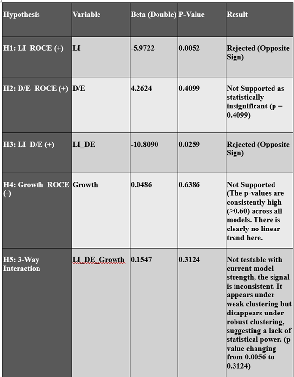

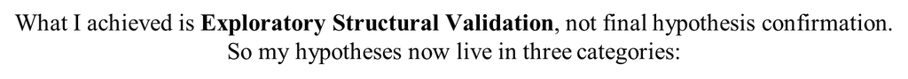

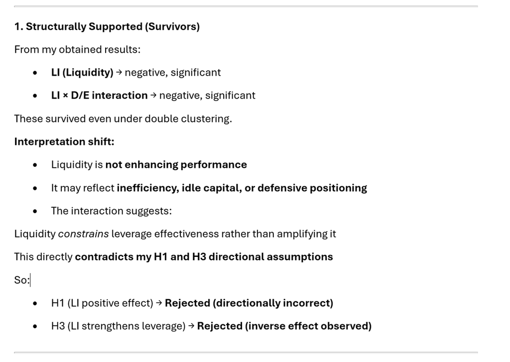

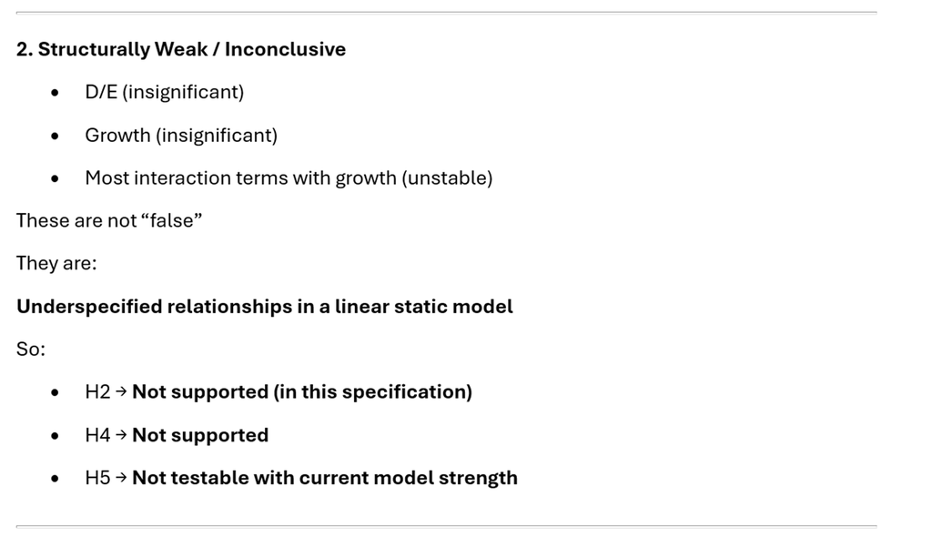

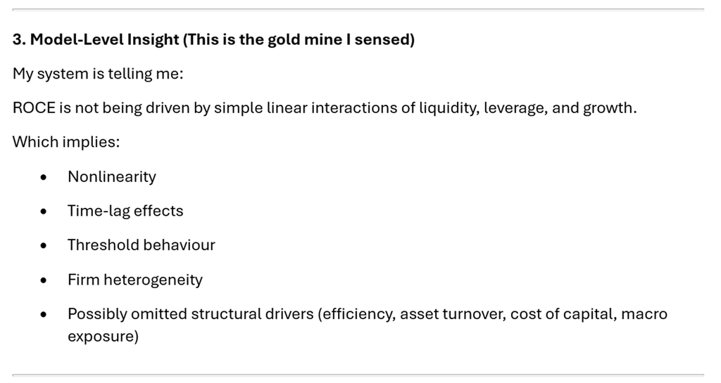

## **Opportunity for Future Research work.**

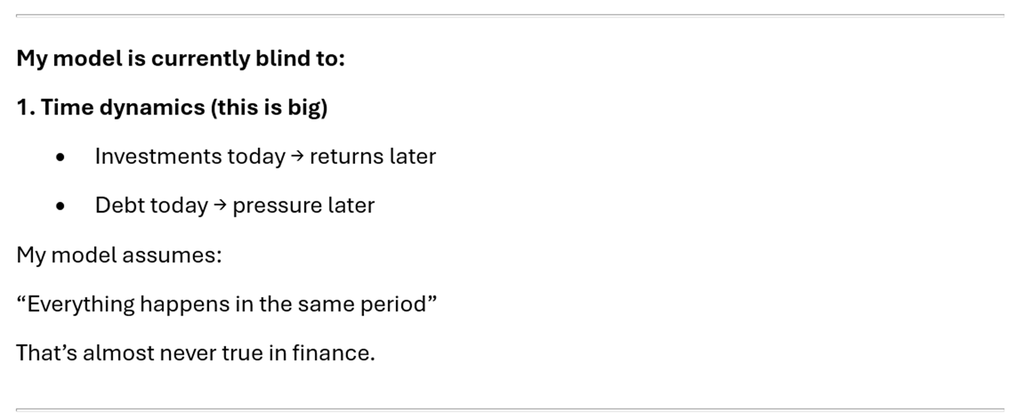

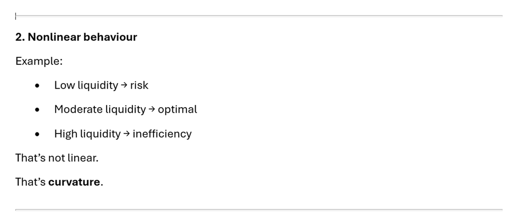

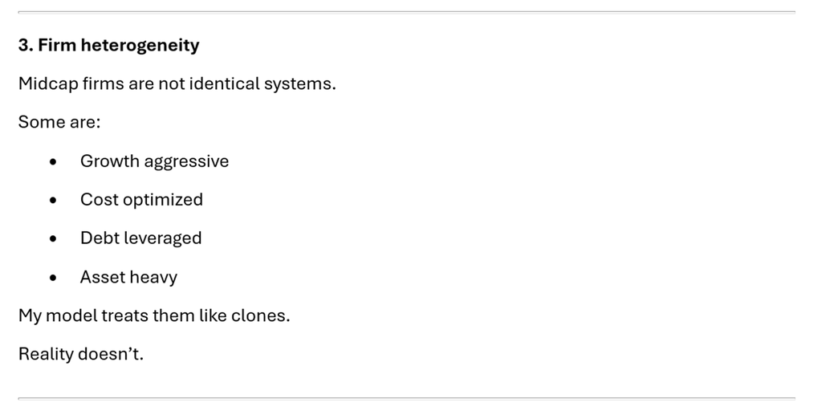

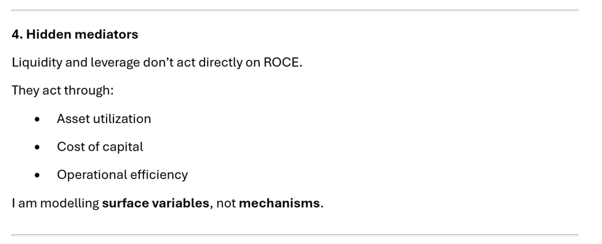

# **All of the above 4 present limitations are "The Golden Opportunities" for my future Research work for my Doctoral thesis.**

**===================================================================================================**